# Disruption of taxi industry in Croatia through media lenses

Majetic, F. and Sikic, L.

22 veljaèa, 2021

# RESEARCH BACKGROUND AND CONTEXT

# DATA COLLECTION AND METHODOLOGY

## Methodology

We analyze Uber text corpus with standard descriptive statistics like word count, word occurrences through time, term frequency, word correlations and sentiment analysis. The term frequency (tf) measures how often a word occurs in a document and inverse term frequency (itf) extends this concept by decreasing the weight for commonly used words and increasing the weight for words that are not used often a collection of documents. We combine these two concepts to calculate a term’s TF-IDF statistic by the multiplication of the two quantities (tf and idf) and achieve a measure of the frequency of a term adjusted for how rarely it is used. Word correlations count common pairs of words co-appearing within the same newspaper article and we use this measure to investigate terms correlated with most important words.

The sentiment analysis is made on the basis of the Croatian Sentiment Lexicon (CroSentiLex) (http://takelab.fer.hr/sentilex) which contains 37000 words ranked by positivity and negativity according to the algorithmically assigned scores. The analyzed text corpus was merged with CroSentiLex dictionary to attribute each word with the positivity and negativity score. The difference in scores between positive and negative words was calculated and the nett scores per word were multiplied by the number of respective word occurrences in each time period (quarter) to attain the aggregate measure of sentiment. Higher sentiment score is therefore related to more positive sentiment and vice versa.

## Insigthts from the data and topic identification

The Table X shows most important words in the full text corpus. All words with more than 100 occurrences are shown along with the respective number of occurences and relative share of the term in the full corpus.

| Word | N | Ratio |
| --- | --- | --- |
| ae | 534 | 1.49% |
| uber | 490 | 1.37% |
| vozaea | 185 | 0.52% |
| transport | 173 | 0.48% |
| taxi drivers | 171 | 0.48% |
| vehicles | 167 | 0.47% |
| law | 156 | 0.43% |
| kuna | 141 | 0.39% |
| zagreb | 128 | 0.36% |
| traffic | 115 | 0.32% |
| vozaei | 110 | 0.31% |
| service | 104 | 0.29% |
| vea | 104 | 0.29% |

The Table X shows the most important bigrams.

| Bigram | N | Ratio |
| --- | --- | --- |
| road traffic | 83 | 0.4% |
| sea traffic | 55 | 0.26% |
| partnera vozaea | 37 | 0.18% |
| milion kuna | 31 | 0.15% |
| new law | 30 | 0.14% |

The most correlated words are shown in the Graph X.

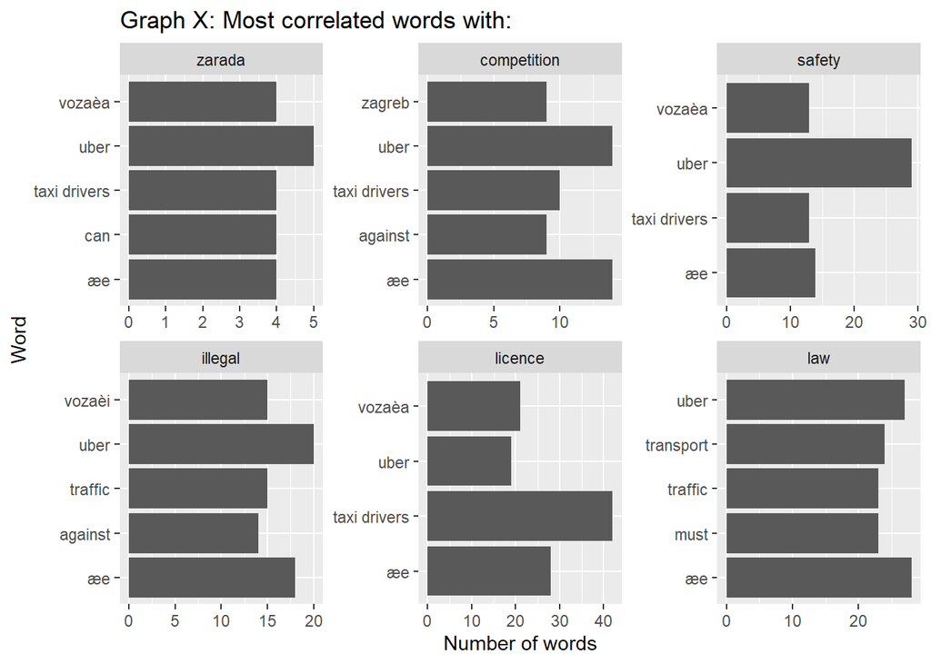

Time dynamics of most common word are shown on the Graph X.

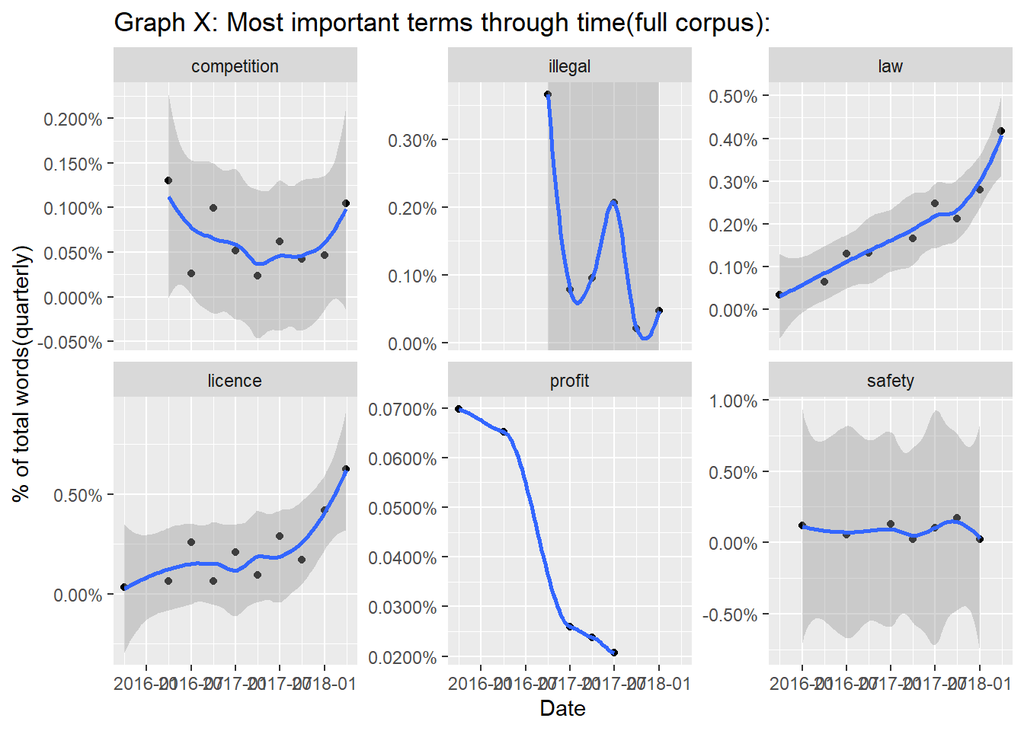

# RESULTS AND DISCUSSION

## Corpus conflict

Most important unigrams and bigrams from the corpus conflict are shown in the Table X and Table X.

| Word | N | Ratio |
| --- | --- | --- |
| ae | 268 | 1.39% |
| uber | 222 | 1.15% |
| law | 135 | 0.7% |
| taxi drivers | 125 | 0.65% |
| vehicles | 112 | 0.58% |

| Bigram | N | Ratio |
| --- | --- | --- |
| road traffic | 66 | 0.59% |
| sea traffic | 45 | 0.4% |
| new law | 29 | 0.26% |
| milion kuna | 26 | 0.23% |

Graph X shows most correlated words with selected important words from corpus "conflict.

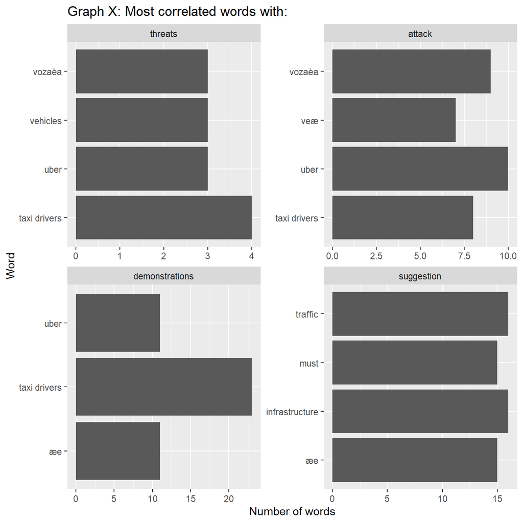

Graph X shows most important terms through time on the quarterly basis.

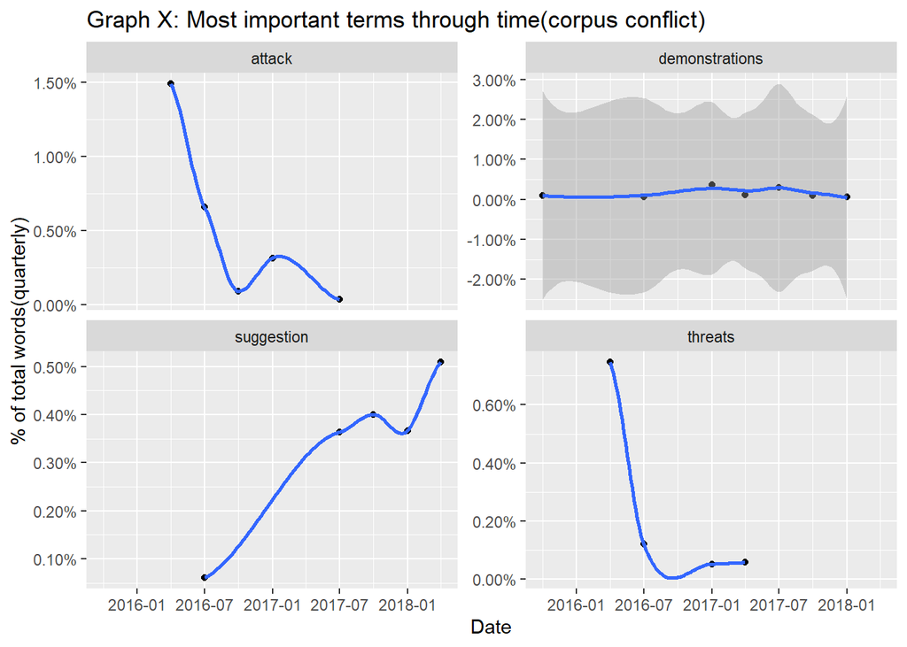

## Topic analysis

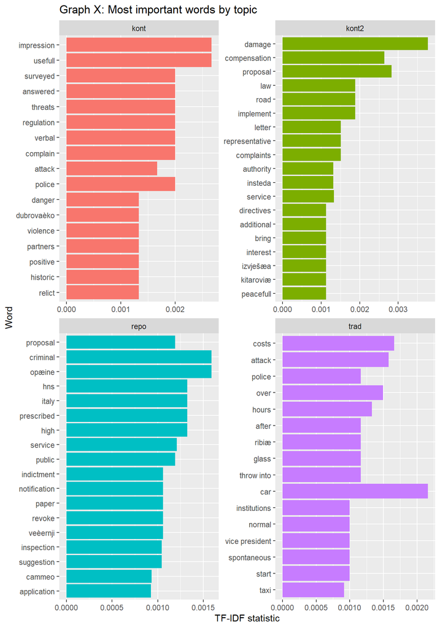

## Sentiment analysis

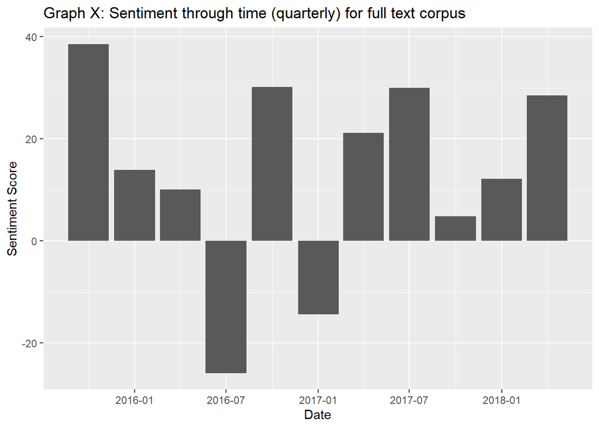

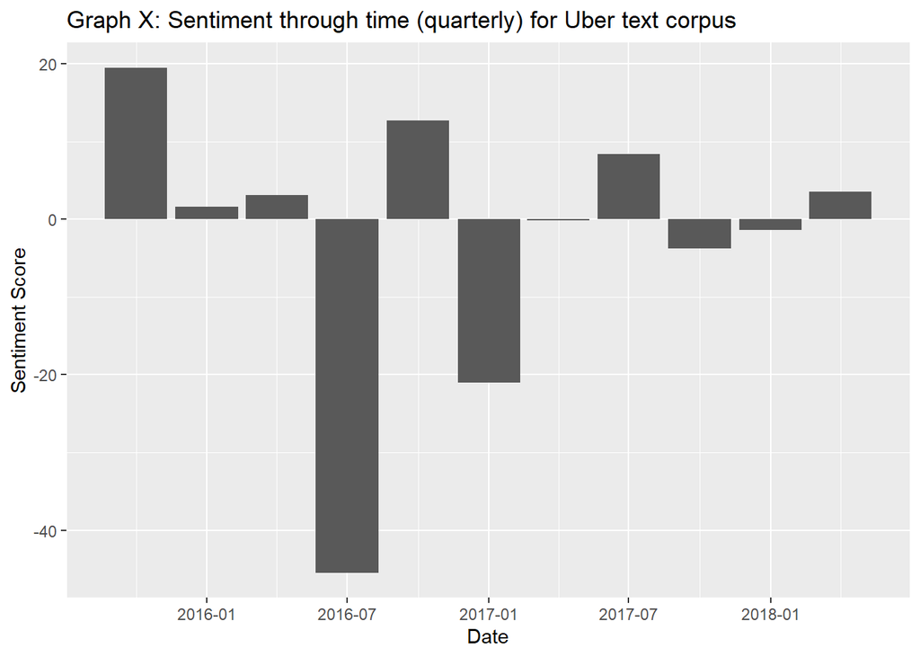

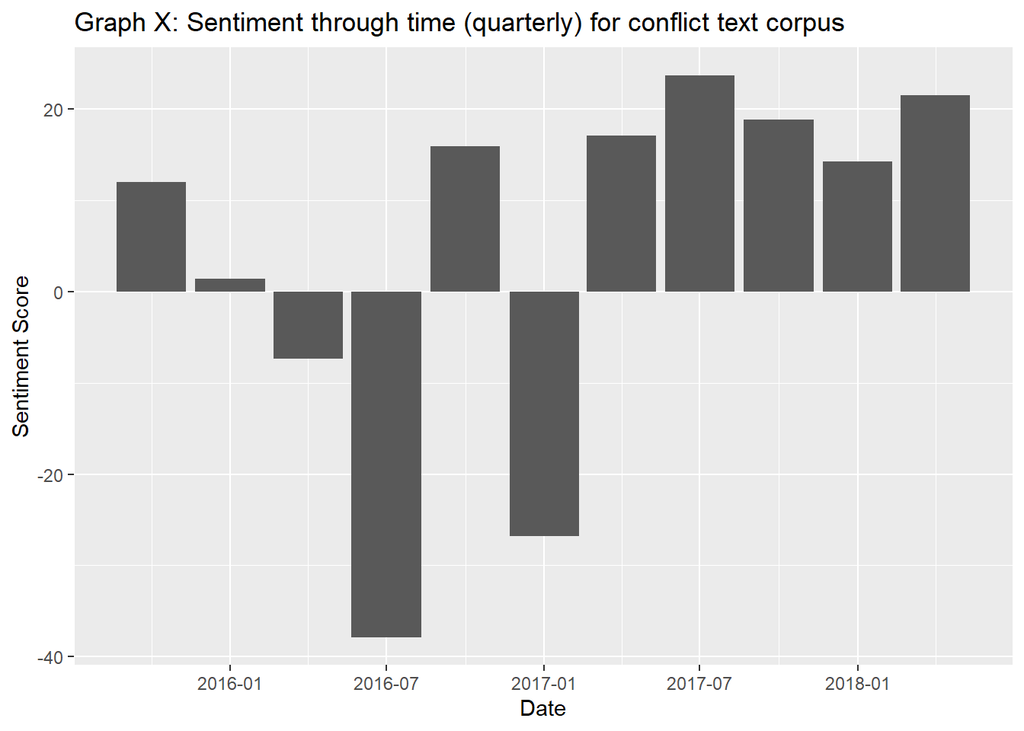